# Reproducible Research Project 1

Aisling O’Connor

2022-10-15

```r
knitr::include_graphics(path = "~/Documents/Coursera/Project")
```

[figure not shown]

Data is recorded through a personal activity monitoring device which is collected every 5 mins throughout the day. The dataset has two months of data (Oct and Nov 2012) from an anonymous individual and details the number of steps taken in 5 minute intervals per day.

To access location of dataset follow the link below:

Dataset: [Activity monitoring data](https://github.com/rdpeng/RepData_PeerAssessment1/raw/master/activity.zip) [52K]

Dataset variables:

- **steps**: Number of steps taking in a 5-minute interval (missing values are coded as NA)
- **date**: The date on which the measurement was taken in YYYY-MM-DD format
- **interval**: Identifier for the 5-minute interval in which measurement was taken

## What is mean total number of steps taken per day?

### 1. Calculate the total number of steps taken per day

```r
download.file("https://github.com/Ash854/RepData_PeerAssessment1/blob/master/activity.zip", "activity.zip")
wd <- getwd()
unzip(wd, files = NULL, list = FALSE, overwrite = TRUE, exdir = "wd", unzip = getOption("unzip"))

activitydata <- read.csv("activity.csv")

## Process/transform the data (if necessary) into a format suitable for your analysis
## You can ignore the missing values in the dataset.

activitydata$date <- as.Date(strptime(activitydata$date, format="%Y-%m-%d"))

##Calculate the total number of steps taken per day

PerDay <- aggregate(steps ~ date, activitydata, sum, na.rm=TRUE)
```

### 2. Make a histogram of the total number of steps taken each day

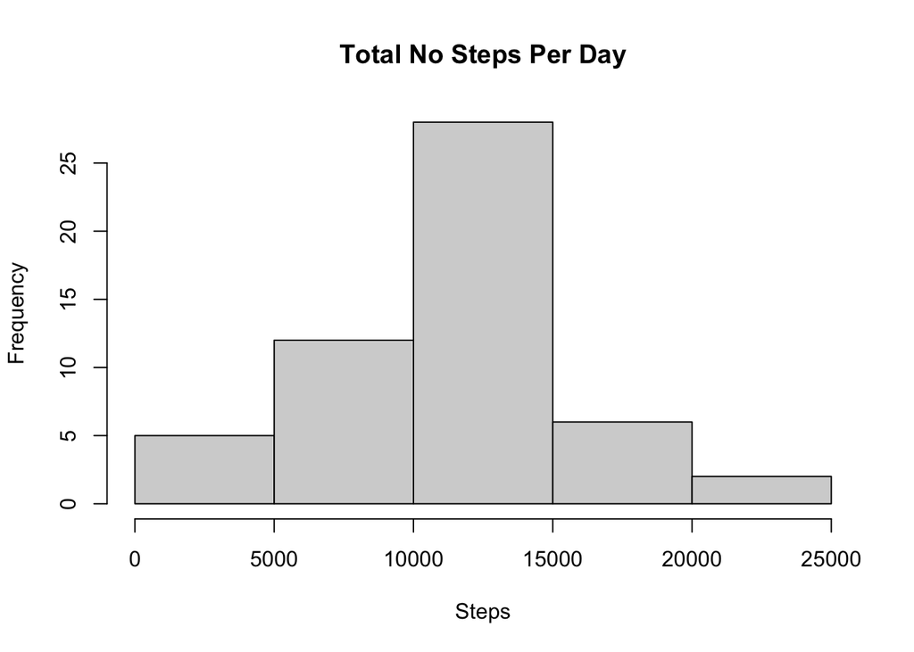

```r
hist(PerDay$steps, xlab = "Steps", main = "Total No Steps Per Day")
```

### 3. Calculate and report the mean and median of the total number of steps taken per day

```r
meanPerDay <- mean(PerDay$steps)
meanPerDay
```

```
## [1] 10766.19
```

```r
medianPerDay <- median(PerDay$steps)
medianPerDay
```

```
## [1] 10765
```

## What is the average daily activity pattern?

### 1. Make a time series plot (i.e. type = “l”) of the 5-minute interval (x-axis) and the average number of steps taken, averaged across all days (y-axis)

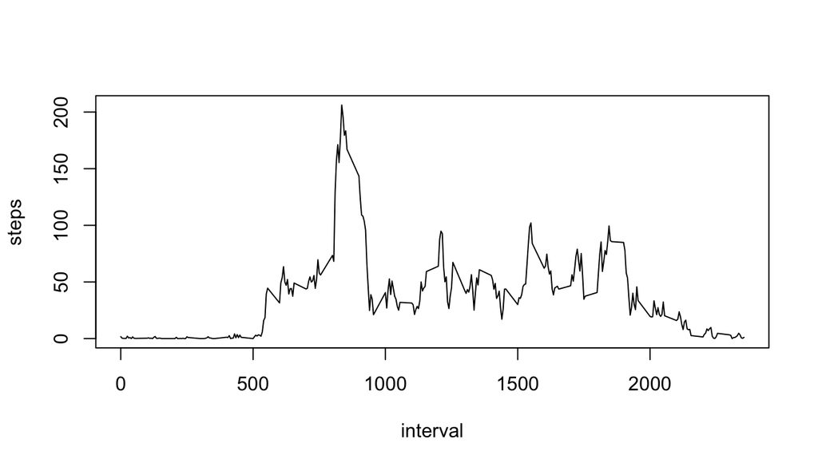

```r
Per5MinInterval<-aggregate(steps~interval, data=activitydata, mean, na.rm=TRUE)
plot(steps~interval, data=Per5MinInterval, type="l")
```

### 2. Which 5-minute interval, on average across all the days in the dataset, contains the maximum number of steps?

```r
MaxStepInterval <- Per5MinInterval[which.max(Per5MinInterval$steps),]$interval
MaxStepInterval
```

```
## [1] 835
```

## Imputing missing values

### 1. Calculate and report the total number of missing values in the dataset.

```r
totalMissingValues <- sum(is.na(activitydata$steps))
totalMissingValues
```

```
## [1] 2304
```

### 2. Devise a strategy for filling in all of the missing values in the dataset.

```r
library(plyr)
library(dplyr)
library(Hmisc)
imputeddata = ddply(activitydata, "interval", mutate,
                         imputed.steps = impute(steps, mean))
```

### 3. Create a new dataset that is equal to the original dataset but with the missing data filled in.

```r
orderedimputeddata=imputeddata[order(imputeddata[,2], decreasing=FALSE) ,]
impdata=orderedimputeddata[,c(4,2,3)]
impdata$imputed.steps=as.integer(imputeddata$imputed.steps)
detach("package:Hmisc")
```

### 4. Make a histogram of the total number of steps taken each day

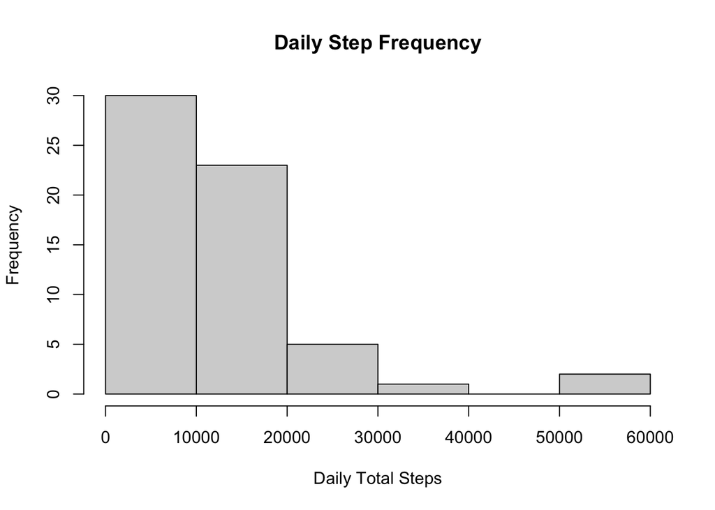

```r
imputeddailytotal=ddply(impdata,"date", summarize, sum=sum(imputed.steps))

hist(imputeddailytotal$sum, xlab= "Daily Total Steps", main = "Daily Step Frequency")
```

#### Calculate and report the mean and median total number of steps taken per day.

```r
meanPerDayImputed <- mean(imputeddailytotal$sum,na.rm=TRUE)
meanPerDayImputed
```

```
## [1] 10749.77
```

```r
medianPerDayImputed <- median(imputeddailytotal$sum, na.rm=TRUE)
medianPerDayImputed
```

```
## [1] 10297
```

#### Do these values differ from the estimates from the first part of the assignment?

```r
MeanDifference <- meanPerDay - meanPerDayImputed
MeanDifference
```

```
## [1] 16.41819
```

```r
MedianDifference <- medianPerDay - medianPerDayImputed
MedianDifference
```

```
## [1] 468
```

#### What is the impact of imputing missing data on the estimates of the total daily number of steps?

There’s a reduction in both mean and median through imputing missing data to estimates of the total daily number of steps. The median is affected to a higher degree of difference than the mean’}

## Are there differences in activity patterns between weekdays and weekends?

### 1. Create a new factor variable in the dataset with two levels – “weekday” and “weekend” indicating whether a given date is a weekday or weekend day.

```r
impdata$dayType <- sapply(impdata$date, function(x) {
  if(weekdays(x) == "Saturday" | weekdays(x) == "Sunday")
  {y <- "Weekend"}
  else {y <- "Weekday"}
  y
})
```

### 2. Make a panel plot containing a time series plot of the 5-minute interval (x-axis) and the average number of steps taken, averaged across all weekday days or weekend days (y-axis).

```r
library(lubridate)
avgstepsimp <- impdata %>% select(-date) %>%
  group_by(interval, dayType) %>%
  summarise(
    imputed.steps = mean(imputed.steps)
  )
```

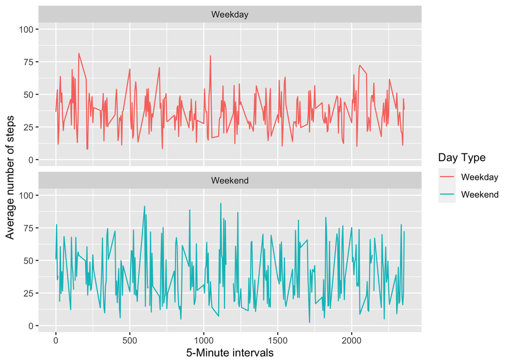

```r
library(ggplot2)

ggplot(avgstepsimp, aes(interval, imputed.steps, color = dayType)) + ylim(0,100) +
  geom_line() +
  facet_wrap(~dayType, nrow = 2) +
  xlab("5-Minute intervals") +
  ylab("Average number of steps") +
  scale_color_discrete(name = "Day Type")
```